# Bezrobocie zarejestrowane w Polsce

## Sytuacja w marcu 2020

### Podczytanie danych z pliku lokalnego sciagnietego z **bdl GUS**

Dane dotycza **bezrobocia zarejestrowanego w Polsce wedlug plci**

```r
marzec_2020 <- read_excel("marzec_2020.xlsx",
    sheet = "DANE", col_types = c("text",
        "text", "text", "text", "text", "numeric",
        "text", "skip"))
```

```r
marzec_2020 %>% head
```

| Kod | Nazwa | Miesiace | Plec | Rok | Wartosc | Jednostka miary |
| --- | --- | --- | --- | --- | --- | --- |
| 0200000 | DOLNOŚLĄSKIE | marzec | ogółem | 2020 | 59495 | osoba |
| 0200000 | DOLNOŚLĄSKIE | marzec | mężczyźni | 2020 | 27667 | osoba |
| 0200000 | DOLNOŚLĄSKIE | marzec | kobiety | 2020 | 31828 | osoba |
| 0400000 | KUJAWSKO-POMORSKIE | marzec | ogółem | 2020 | 65137 | osoba |
| 0400000 | KUJAWSKO-POMORSKIE | marzec | mężczyźni | 2020 | 26611 | osoba |
| 0400000 | KUJAWSKO-POMORSKIE | marzec | kobiety | 2020 | 38526 | osoba |

### Zmianna polskich nazw na angielskie

```r
marzec_2020 <- marzec_2020 %>%
   mutate(Nazwa = str_to_title((Nazwa)),
         Plec = str_replace(Plec, "ogółem", "all"),
         Plec = str_replace(Plec, "mężczyźni", "men"),
         Plec = str_replace(Plec, "kobiety", "women"))
```

### Zmianna nazwy kolumny zawierajace nazwy wojewodztw

```r
names(marzec_2020)
```

```
[1] "Kod"             "Nazwa"
[3] "Miesiace"        "Plec"
[5] "Rok"             "Wartosc"
[7] "Jednostka miary"
```

```r
names(marzec_2020)[2] <- "NAME_1"
names(marzec_2020)
```

```
[1] "Kod"             "NAME_1"
[3] "Miesiace"        "Plec"
[5] "Rok"             "Wartosc"
[7] "Jednostka miary"
```

### Polaczenie danych

```r
marzec_2020 <- marzec_2020 %>%
  select(NAME_1, Kod, Miesiace, Plec, Rok, Wartosc) %>%
  unite("Rok.Plec", c(Rok, Plec), sep = ".")
```

```r
names(marzec_2020)[3] <- "Miesiac"
names(marzec_2020)
```

```
[1] "NAME_1"   "Kod"      "Miesiac"  "Rok.Plec"
[5] "Wartosc"
```

### Postac szeroka zbioru danych

```r
marzec_2020.w <- marzec_2020 %>%
  pivot_wider(
    names_from = Rok.Plec,
    values_from = Wartosc)
```

### Przechowanie nazw wojewodztw

```r
gadm_1sf$NAME_1
```

```
 [1] "Dolnośląskie"        "Kujawsko-Pomorskie"
 [3] "Łódzkie"             "Lubelskie"
 [5] "Lubuskie"            "Małopolskie"
 [7] "Mazowieckie"         "Opolskie"
 [9] "Podkarpackie"        "Podlaskie"
[11] "Pomorskie"           "Śląskie"
[13] "Świętokrzyskie"      "Warmińsko-Mazurskie"
[15] "Wielkopolskie"       "Zachodniopomorskie"
```

### Dolaczenie danych do obiektu *sf* z konturami wojewodztw

```r
gadm_1sf.p <- gadm_1sf %>%
  as.data.frame() %>%
  left_join(marzec_2020.w) %>%
  st_as_sf()
```

```
old-style crs object detected; please recreate object with a recent sf::st_crs()
```

### Mapa dla bezrobocia w marcu 2020

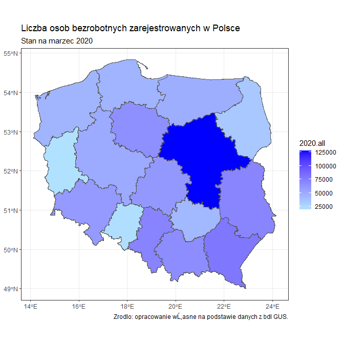

```r
gadm_1sf.p %>%
  ggplot() +
  geom_sf(aes(fill = `2020.all`)) +
  scale_fill_gradient(low = "lightskyblue1", high = "blue") +
  theme_bw() +
  labs(title = "Liczba osob bezrobotnych zarejestrowanych w Polsce",
       subtitle = "Stan na marzec 2020",
       caption = "Zrodlo: opracowanie wĹ‚asne na podstawie danych z bdl GUS.")
```

## Podsumowanie ilosci osob bezrobotnych w wojewodztach Polski w marcu 2020

```r
summary(marzec_2020.w)
```

```
    NAME_1              Kod
 Length:16          Length:16
 Class :character   Class :character
 Mode  :character   Mode  :character



   Miesiac             2020.all         2020.men
 Length:16          Min.   : 19838   Min.   : 8332
 Class :character   1st Qu.: 44174   1st Qu.:19045
 Mode  :character   Median : 55045   Median :23863
                    Mean   : 56840   Mean   :26111
                    3rd Qu.: 67998   3rd Qu.:30563
                    Max.   :127761   Max.   :62994
   2020.women
 Min.   :11506
 1st Qu.:24424
 Median :30473
 Mean   :30729
 3rd Qu.:37238
 Max.   :64767
```

### Sprawdzenie w jakim wojewodztwie wystepuje najwieksza liczba osob bezrobotnych

```r
marzec_2020.w[which(str_detect(marzec_2020.w$`2020.all`, "127761")),]
```

| NAME_1 | Kod | Miesiac | 2020.all | 2020.men | 2020.women |
| --- | --- | --- | --- | --- | --- |
| Mazowieckie | 1400000 | marzec | 127761 | 62994 | 64767 |

### Sprawdzenie w jakim wojewodztwie wystepuje najmniejsza liczba osob bezrobotnych

```r
marzec_2020.w[which(str_detect(marzec_2020.w$`2020.all`, "19838")),]
```

| NAME_1 | Kod | Miesiac | 2020.all | 2020.men | 2020.women |
| --- | --- | --- | --- | --- | --- |
| Lubuskie | 0800000 | marzec | 19838 | 8332 | 11506 |

## Sytuacja w marcu 2020 w wojewodztwie podlaskim

```r
Podlasie_marzec_2020 <- read_excel("Podlasie_marzec_2020.xlsx",
    sheet = "DANE")
Podlasie_marzec_2020 <- Podlasie_marzec_2020[,c(1:6)]
```

### Zmianna polskich nazw na angielskie

```r
Podlasie_marzec_2020 <- Podlasie_marzec_2020 %>%
    mutate(Nazwa = str_to_title((Nazwa)),
         Plec = str_replace(Plec, "ogółem", "all"),
         Plec = str_replace(Plec, "mężczyźni", "men"),
         Plec = str_replace(Plec, "kobiety", "women"))
```

```r
Podlasie_marzec_2020 <- Podlasie_marzec_2020 %>%
  select(Nazwa, Kod, Miesiace, Plec, Rok, Wartosc) %>%
  unite("Rok.Plec", c(Rok, Plec), sep = ".")
```

```r
names(Podlasie_marzec_2020)[3] <- "Miesiac"
names(Podlasie_marzec_2020)
```

```
[1] "Nazwa"    "Kod"      "Miesiac"  "Rok.Plec"
[5] "Wartosc"
```

### Postac szeroka zbioru danych

```r
Podlasie_marzec_2020.w <- Podlasie_marzec_2020 %>%
  pivot_wider(
    names_from = Rok.Plec,
    values_from = Wartosc)
```

```r
p1_podlaskie <- Podlasie_marzec_2020.w %>%
  filter(str_sub(Kod, start = 1, end = 2) == "20") %>%
  mutate(Podlaskie = Nazwa)
```

```r
g1_podlaskie <- gadm_2sf %>%
  filter(NAME_1 == "Podlaskie") %>%
  arrange(NAME_2)
```

```
old-style crs object detected; please recreate object with a recent sf::st_crs()
```

```r
p1_podlaskie <- p1_podlaskie %>%
  mutate(NAME_2 = g1_podlaskie$NAME_2)
```

## Ilustracja graficzna danych na mapie

### Podzial na plec

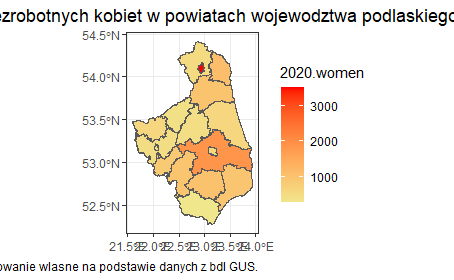

```r
g1_podlaskie %>%
  left_join(p1_podlaskie) %>%
  ggplot() +
  geom_sf(aes(fill = `2020.women`)) +
  scale_fill_gradient(low = "khaki", high = "red") +
  theme_bw() +
  theme(
        plot.title = element_text(hjust = 0.5, size = rel(1.2))) +
  labs(title = "Liczba bezrobotnych kobiet w powiatach wojewodztwa podlaskiego",
       caption = "Zrodlo: opracowanie wlasne na podstawie danych z bdl GUS.")
```

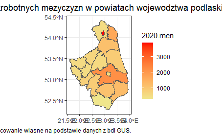

```r
g1_podlaskie %>%
  left_join(p1_podlaskie) %>%
  ggplot() +
  geom_sf(aes(fill = `2020.men`)) +
  scale_fill_gradient(low = "khaki", high = "red") +
  theme_bw() +
  theme(
        plot.title = element_text(hjust = 0.5, size = rel(1.2))) +
  labs(title = "Liczba bezrobotnych mezyczyzn w powiatach wojewodztwa podlaskiego",
       caption = "Zrodlo: opracowanie wlasne na podstawie danych z bdl GUS.")
```

```r
 p + transition_reveal(Wartosc) +
  labs(title = "Wykres liczby osób bezrobotnych na Podlasiu marcu 2020",
       caption = "Zrodlo: opracowanie wlasne na podstawie danych z bdl GUS.")
```

[output not shown]

[output not shown]

[output cut: 238 more lines]

[figure not shown]

## Podsumowanie ilosci osob bezrobotnych w powiatach wojewodztwa podlaskiego

```r
summary(p1_podlaskie)
```

```
    Nazwa               Kod
 Length:17          Length:17
 Class :character   Class :character
 Mode  :character   Mode  :character



   Miesiac             2020.all       2020.men
 Length:17          Min.   : 606   Min.   : 300
 Class :character   1st Qu.:1078   1st Qu.: 581
 Mode  :character   Median :1529   Median : 791
                    Mean   :2002   Mean   :1071
                    3rd Qu.:2139   3rd Qu.:1158
                    Max.   :7426   Max.   :3912
   2020.women      Podlaskie
 Min.   : 306.0   Length:17
 1st Qu.: 492.0   Class :character
 Median : 640.0   Mode  :character
 Mean   : 930.9
 3rd Qu.: 999.0
 Max.   :3514.0
    NAME_2
 Length:17
 Class :character
 Mode  :character
```

### Sprawdzenie w jakim powiecie wystepuje najwieksza liczba osob bezrobotnych

```r
p1_podlaskie[which(str_detect(p1_podlaskie$`2020.all`, "7426")),]
```

| Nazwa | Kod | Miesiac | 2020.all | 2020.men | 2020.women | Podlaskie | NAME_2 |
| --- | --- | --- | --- | --- | --- | --- | --- |
| Powiat M.białystok | 2061000 | marzec | 7426 | 3912 | 3514 | Powiat M.białystok | Suwałki (City) |

### Sprawdzenie w jakim powiecie wystepuje najmniejsza liczba osob bezrobotnych

```r
p1_podlaskie[which(str_detect(p1_podlaskie$`2020.all`, "606")),]
```

| Nazwa | Kod | Miesiac | 2020.all | 2020.men | 2020.women | Podlaskie | NAME_2 |
| --- | --- | --- | --- | --- | --- | --- | --- |
| Powiat Suwalski | 2012000 | marzec | 606 | 300 | 306 | Powiat Suwalski | Siemiatycze |

## Podsumowanie ogolnej liczby osob bezrobotnnych na przestrzeni roku

### Podczytanie danych z pliku lokalnego sciagnietego z **bdl GUS**

Dane dotyczą **bezrobocia zarejestrowanego w Polsce według plci**

```r
bezrobocie_ogolem <- read_excel("bezrobocie_ogolem.xlsx",
    sheet = "DANE")
bezrobocie_ogolem <- bezrobocie_ogolem[,c(1:6)]
```

### Zmianna polskich nazw na angielskie

```r
bezrobocie_ogolem <- bezrobocie_ogolem %>%
    mutate(Nazwa = str_to_title((Nazwa)),
         Plec = str_replace(Plec, "ogółem", "all"),
         Plec = str_replace(Plec, "mężczyźni", "men"),
         Plec = str_replace(Plec, "kobiety", "women"))
```

```r
bezrobocie_ogolem <- bezrobocie_ogolem %>%
  select(Nazwa, Kod, Miesiace, Plec, Rok, Wartosc) %>%
  unite("Rok.Plec", c(Rok, Plec), sep = ".")
```

```r
names(bezrobocie_ogolem)[3] <- "Miesiac"
names(bezrobocie_ogolem)
```

```
[1] "Nazwa"    "Kod"      "Miesiac"  "Rok.Plec"
[5] "Wartosc"
```

### Postac szeroka zbioru danych

```r
bezrobocie_ogolem.w <- bezrobocie_ogolem %>%
  pivot_wider(
    names_from = Rok.Plec,
    values_from = Wartosc)
```

```r
summary(bezrobocie_ogolem.w)
```

```
    Nazwa               Kod
 Length:204         Length:204
 Class :character   Class :character
 Mode  :character   Mode  :character




   Miesiac             2020.all         2020.men
 Length:204         Min.   : 19838   Min.   :  8332
 Class :character   1st Qu.: 44686   1st Qu.: 19256
 Mode  :character   Median : 59850   Median : 27437
                    Mean   :107902   Mean   : 49305
                    3rd Qu.: 71559   3rd Qu.: 32110
                    Max.   :922197   Max.   :420957
                    NA's   :153      NA's   :153
   2020.women        2019.all         2019.men
 Min.   : 11506   Min.   : 17914   Min.   :  7154
 1st Qu.: 25392   1st Qu.: 41112   1st Qu.: 17161
 Median : 31828   Median : 57163   Median : 24324
 Mean   : 58597   Mean   :104091   Mean   : 45634
 3rd Qu.: 39599   3rd Qu.: 69297   3rd Qu.: 30902
 Max.   :503638   Max.   :984739   Max.   :443287
 NA's   :153      NA's   :34       NA's   :34
   2019.women
 Min.   : 10633
 1st Qu.: 23750
 Median : 31407
 Mean   : 58457
 3rd Qu.: 39667
 Max.   :541452
 NA's   :34
```

```r
p + transition_states(Miesiac, wrap = FALSE) +
  shadow_mark()+
  labs(title = "Wykres liczby osób bezrobotnych ogolem na przestrzeni roku",
       caption = "Zrodlo: opracowanie wlasne na podstawie danych z bdl GUS.")
```

[output not shown]

[figure not shown]